# Examples of Using Container Images in Practice

**Overview**

- **Teaching:** 10
- **Exercises:** 15
- **Questions:**
  - How can I use Docker for my own work?
- **Objectives:**
  - Use existing container images and Docker in a research project.

Now that we have learned the basics of working with Docker container images and containers, let’s apply what we learned to an example workflow.

You may choose one or more of the following examples to practice using containers.

## GitHub Actions Example

In this GitHub Actions example, you can learn more about continuous integration in the cloud and how you can use container images with GitHub to automate repetitive tasks like testing code or deploying websites. Our specific example will show a neat way to build a simple website that goes with any project you might have going.

### GitHub Actions

GitHub Actions provide a means of automating repetitive tasks to support maintaining software projects. Some examples include:

- Testing if your software works correctly (Continuous Integration)
- Building components for distribution to your users (Continuous Deployment)
- Building documentation

These are tasks that you could do on your own computer, but consider the following cases:

- Your software works on your computer, but you forgot to mention this one crucial package that is required for correct operation.
- Your software used to work, but since the last update something broke.
- Someone else contributed to your package but didn’t run the same version of the document converter: the documentation looks different now.

These are just some of the bad things that may happen. To address these issues, it is often desirable to have a consistent, controlled environment in which to run these tasks, collectively known as CI/CD. GitHub can perform these actions for you. You configure GitHub Actions by providing a workflow configuration file (in YAML format) that GitHub Actions reads and runs. The tasks are run, behind the scenes, inside Docker containers. If your project is open source, this service is entirely free of charge. Competing platforms have similar services for which the syntax may vary slightly, but they are all grounded in the use of some form of containers (Docker or otherwise). We will demonstrate the use of a Docker container in deploying a small website presenting a GitHub project.

### Building content for deployment via GitHub Pages with Pandoc

Suppose you have a GitHub project with a README.md file and would like to turn it into HTML to host as a web page via GitHub Pages. A common problem in documenting and testing software is to keep relevant content in a single location. In a GitHub project this location is the README, however it will look a lot more professional if you also have a custom website where people can find downloads, documentation etc. This website could become part of a larger portfolio of all your projects on GitHub.

It would be nice if such a page was updated automatically every time you update other parts of the project.

A fabulous tool for building web content from Markdown files is Pandoc. You could call it the swiss army knife of document conversion: it is very, very versatile. In this instance we will only use its most basic operation. (If you are familiar with RMarkdown: Pandoc is what powers RMarkdown).

**Why Pandoc?**

There are other engines that can do this for you, but here are some features that win some people over:

- Supports citations (from BibTeX or CSL database)
- Rendered equations (using MathJax, optionally numbered)
- Code highlighting
- Highly customizable

We take you through the process of creating a project on GitHub from scratch, converting the README.md file to HTML format and then uploading it to a separate `gh-pages` branch within the GitHub project. First let’s take a look at what the end product will look like. We have a project ([example here](https://github.com/jhidding/readme-pages)) with a `main` branch that includes a README.md file.

[figure not shown]

We can use Pandoc to turn this README.md file into a simple static website.

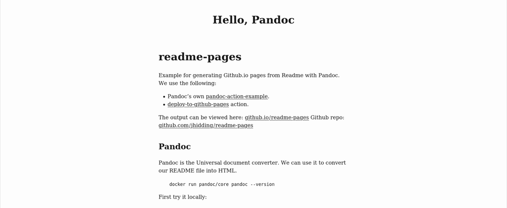

If we switch to the `gh-pages` branch in GitHub we can see where this page is hosted from.

[figure not shown]

Only `index.html` and `.nojekyll` files are present. The .nojekyll file prevents GitHub from processing the repository content with Jekyll, the approach that is used by default when creating a GitHub Pages website. Instead, Pages skips the Jekyll processing stage and simply deploys the content in the specified branch to the GitHub Pages server. So how do we set this up?

#### Create a GitHub Project

Create a github project with a short `README.md`. To do this:

- go to `github.com` and make sure you’re logged in
- click the green “New” button at the top right and fill out the form to create the new project
- clone the new project to your computer. The instructions for doing so will be shown in the dialog on GitHub, or you can also see [Software Carpentry lesson on Version Control with Git](https://swcarpentry.github.io/git-novice/07-github/index.html), or the example below:

```bash
git clone <your-repo-url>
cd <repo-name>
```

#### Using Pandoc to Create a Website

Now that we have cloned the repository we can generate the HTML locally using Pandoc.

Pandoc is a universal document converter. It reads and writes between very many different file formats, including many flavours of Markdown, HTML, LaTeX, Word, RTF, rst and many more. We use it to generate static websites from Markdown.

First, let’s download a container with pandoc installed and run it to see what the pandoc version is.

```bash
docker container run pandoc/core --version
```

```
Unable to find image 'pandoc/core:latest' locally
latest: Pulling from pandoc/core
f84cab65f19f: Pull complete
f95e84a31132: Pull complete
5d5ebbd90555: Pull complete
d084fb969d20: Pull complete
Digest: sha256:af1d118e3280ffaf6181af5a9f87ef0c010af9b5877053b750be33d0c47cc6ce
Status: Downloaded newer image for pandoc/core:latest
pandoc 2.12
Compiled with pandoc-types 1.22, texmath 0.12.1.1, skylighting 0.10.4,
citeproc 0.3.0.8, ipynb 0.1.0.1
User data directory: /root/.local/share/pandoc
Copyright (C) 2006-2021 John MacFarlane. Web:  https://pandoc.org
This is free software; see the source for copying conditions. There is no
warranty, not even for merchantability or fitness for a particular purpose.
```

Now, we can run pandoc on our `README.md` file by including our current directory and the `README.md` file as part of the `docker container run` command:

```bash
docker container run --mount type=bind,source=${PWD},target=/tmp pandoc/core /tmp/README.md
```

```
<h1 id="readme-pages">readme-pages</h1>
<p>Example for generating GitHub.io pages from Readme with Pandoc.</p>
```

Here, the `--mount type=bind,source=${PWD},target=/tmp` flag says to take the directory at `${PWD}` and make it available inside the container as `/tmp`. Then `pandoc` can read the source file (`README.md`) and convert it to HTML. While this HTML is valid, it doesn’t show the complete structure of a standalone HTML document. For that we need to add the `--standalone` argument to the pandoc command. Also we can redirect the output to create a HTML file in the `build` directory.

```bash
mkdir -p build
docker container run --mount type=bind,source=${PWD},target=/tmp pandoc/core /tmp/README.md --standalone --output=/tmp/build/index.html
```

```
[WARNING] This document format requires a nonempty <title> element.
  Defaulting to 'README' as the title.
  To specify a title, use 'title' in metadata or --metadata title="...".
```

To suppress the warning message we may add the following lines at the top of the `README.md` file:

```
---
title: Hello, Pandoc
---
```

Or add the mentioned `--metadata title="..."` to the command line.

Once we’ve made all of these changes, and produced the output we want, we can check it, using this command:

```bash
cat build/index.html
```

```
<!DOCTYPE html>
<html xmlns="http://www.w3.org/1999/xhtml" lang="" xml:lang="">
<head>
  <meta charset="utf-8" />
... etc
```

We now have tested our website deployment workflow - given the source files from GitHub, we can use a Docker container and command to generate our website. We now want to automate this process via GitHub Actions.

#### Automating Deployment on GitHub Actions

GitHub Actions is a cloud service for automating continuous integration and deployment. This means we can have GitHub build our website and publish it on `github.io` automatically at every commit.

Go to the GitHub project page you created earlier and click on “Actions”. Because we have no active workflows yet, we are taken immediately to a menu for creating a new one. We will skip the templates and click on “set up a workflow yourself”. The configuration format is YAML.

The first entry is the **name** of the workflow

```yaml
name: Deploy pages
```

Next we specify **when** this workflow is run. In this case: every time content is pushed to the `main` branch

```yaml
on:
  push:
    branches:
      - main
```

Now we tell GitHub **what** to do.

```yaml
jobs:
  # a free machine-readable name for this job
  deploy:
    # Set permissions for this specific job to enable it to write to the gh-pages branch
    permissions:
      contents: write
    # specify the base operating system
    runs-on: ubuntu-latest
    steps:
      # fetch the contents of the repository
      - name: Checkout repo content
        uses: actions/checkout@v2
      - name: Prepare build environment
        run: |   # multiple Bash commands follow
          mkdir -p build
          touch build/.nojekyll
```

Now for the Docker bit:

```yaml
      - name: Run pandoc
        # Always specify a version!
        uses: docker://pandoc/core:2.12
        with:
          args: >-  # multi-line argument
            --standalone
            --output=build/index.html
            README.md
      - name: Deploy on github pages
        # Use a third-party plugin to upload the content
        uses: JamesIves/github-pages-deploy-action@4.1.0
        with:
          branch: gh-pages
          folder: build
```

We may recognize the command-line that we had previously. Notice that we don’t need to specify the `--mount` flag. GitHub Actions arranges the Docker environment such that the files are in the correct location. The last step uploads the `build` directory to the `gh-pages` branch.

Now we should enable GitHub Pages on this repository: go to the “Settings” tab and scroll down to “GitHub Pages”. There we select the root folder in the `gh-pages` branch. After a few (tens) of seconds the page should be up.

## Using Containers on an HPC Cluster

It is possible to run containers on shared computing systems run by a university or national computing center. As a researcher, you can build container images and test containers on your own computer and then run your full-scale computing work on a shared computing system like a high performance cluster or high throughput grid.

The catch? Most university and national computing centers do not support *running* containers with Docker commands, and instead use a similar tool called Singularity or Shifter. However, both of these programs can be used to run containers based on Docker container images, so often people create their container image as a Docker container image, so they can run it using either of Docker or Singularity.

**Tip**

You can find more detail about using Singularity in the [singularity-introduction](https://carpentries-incubator.github.io/singularity-introduction/) Carpentries workshop.

**Singularity Command Line Interface**

Like we did with Docker, try to work out what commands Singularity has. Which one do you think is the equivalent of `docker run`?

**Note**

`singularity run` behaves similarly to `docker run`, but as we will see, the arguments are somewhat different.

### Running Docker Containers

Since Singularity containers have their own file format, if we have a Docker image we want to run, it first has to be converted. We can do this using `singularity pull`. For example, we can pull the container we previously pushed to Docker Hub:

```bash
singularity pull docker://alice/alpine-python
```

```bash
singularity run alpine_python.sif
```

### Singularity Exec

```bash
apptainer exec alpine_python.sif python -c 'print(1 + 1)'
```

For more information, check these additional resources:

- [Introduction to Singularity](https://carpentries-incubator.github.io/singularity-introduction/): See the episode titled “Running MPI parallel jobs using Singularity containers”
- [Container Workflows at Pawsey](https://pawseysc.github.io/container-workflows/): See the episode titled “Run containers on HPC with Shifter (and Singularity)”

**Key Points**

- There are many ways you might use Docker and existing container images in your research project.

| ← Previous | Next → |
| --- | --- |